# Homework 11

Solutions will be available after Monday, November 9, 2026.

## Question 1: Implementing K-means

K-means is a relatively simple algorithm that we can write ourselves. For Questions 1 and 2, do not use an existing function that performs K-means directly.

Generate 10 observations with two independent standard normal coordinates. Set a random seed and report it. Randomly assign the observations to $K=2$ clusters, making sure neither cluster is empty. Let $C(i)$ denote the cluster assigned to observation $x_i$, and let $m_k$ denote the mean of cluster $k$.

1. Perform one iteration: calculate the cluster means, then assign each observation to its closest mean using Euclidean distance. Report the means and updated assignments, and plot the observations colored by their updated assignments.
2. Write a function that repeats these two steps until the assignments stop changing or a specified maximum number of iterations is reached. Your function should work for a data matrix with any number of variables and a chosen number of clusters $K$. Start from a nonempty assignment to each cluster; if a cluster becomes empty during iteration, keep its previous mean. Recalculate the cluster means from the final assignments before returning them. Return the final assignments, cluster means, and within-cluster sum of squares,

   $$\sum_{k=1}^K\sum_{i:\,C(i)=k}\lVert x_i-m_k\rVert^2.$$
3. Apply your function to the same 10 observations from two different random initial assignments. Report the final plots, cluster means, and within-cluster sums of squares. Do the two runs produce the same grouping and objective value? Explain your findings.

**Answer 1.** I used seed **432** (NumPy `default_rng`) for the data, the starting assignment in part a, and the two random starts in part c, all drawn in that order from one generator.

**Show the workflow**

```python
import numpy as np
import pandas as pd
import matplotlib.pyplot as plt

def random_assignment(n, K, rng):
    """Random cluster labels 0..K-1, redrawn until every cluster is nonempty."""
    while True:
        labels = rng.integers(0, K, n)
        if len(np.unique(labels)) == K:
            return labels

def cluster_means(X, labels, K, previous=None):
    """Mean of each cluster; an empty cluster keeps its previous mean."""
    M = np.empty((K, X.shape[1])) if previous is None else previous.copy()
    for k in range(K):
        if np.any(labels == k):
            M[k] = X[labels == k].mean(axis=0)
    return M

def assign(X, M):
    """Closest mean in Euclidean distance (ties go to the lower label)."""
    d2 = ((X[:, None, :] - M[None, :, :]) ** 2).sum(axis=2)
    return d2.argmin(axis=1)

def my_kmeans(X, K, init, max_iter=100):
    X = np.asarray(X, dtype=float)
    labels = np.asarray(init).copy()
    M = cluster_means(X, labels, K)
    n_iter = 0
    for n_iter in range(1, max_iter + 1):
        M = cluster_means(X, labels, K, previous=M)
        new_labels = assign(X, M)
        if np.array_equal(new_labels, labels):
            break
        labels = new_labels
    M = cluster_means(X, labels, K, previous=M)           # final means from final labels
    wss = sum(((X[labels == k] - M[k]) ** 2).sum() for k in range(K))
    return {"labels": labels, "means": M, "wss": wss, "iterations": n_iter}

def plot_clusters(ax, X, labels, M, title):
    cols = np.array(["#0072B2", "#D55E00", "#009E73", "#CC79A7", "#E69F00"])
    ax.scatter(X[:, 0], X[:, 1], c=cols[labels], s=55, edgecolor="white", zorder=3)
    ax.scatter(M[:, 0], M[:, 1], c=cols[:len(M)], marker="X", s=170,
               edgecolor="black", zorder=4)
    for i, (a, b) in enumerate(X):
        ax.annotate(i + 1, (a, b), xytext=(5, 4), textcoords="offset points", fontsize=8)
    ax.set(xlabel=r"$x_1$", ylabel=r"$x_2$", title=title)
    ax.set_aspect("equal")

rng = np.random.default_rng(432)
X = rng.standard_normal((10, 2))
start = random_assignment(10, 2, rng)
print(pd.DataFrame(X.round(3), columns=["x1", "x2"], index=range(1, 11)).T.to_string())
print("starting assignment C(i):", start)
```

```
       1      2      3      4      5      6      7      8      9      10
x1  0.708 -1.352  0.086 -1.115 -0.486 -0.534  2.127 -0.812  0.278  0.725
x2 -1.298 -0.064 -0.583  0.238  1.806 -1.988 -0.951  0.358  0.778 -1.760
starting assignment C(i): [1 1 1 1 1 1 1 0 0 1]
```

**a.** One iteration: compute the two means from the random start, then reassign every point to its closest mean.

**Show the workflow**

```
means from the starting assignment:
       x1     x2
0 -0.267  0.568
1  0.020 -0.575
updated assignment C(i): [1 0 1 0 0 1 1 0 0 1]
```

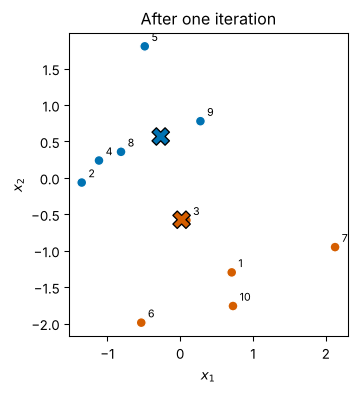

The 10 observations colored by their assignments after one iteration. Crosses mark the means computed from the random start.

```python
M_a = cluster_means(X, start, 2)
updated = assign(X, M_a)
print("means from the starting assignment:\n", pd.DataFrame(M_a.round(3), columns=["x1", "x2"]))
print("updated assignment C(i):", updated)
fig, ax = plt.subplots(figsize=(4.6, 4.2))
plot_clusters(ax, X, updated, M_a, "After one iteration")
plt.tight_layout(); plt.show()
```

The random start puts 8 points in cluster 1 and 2 in cluster 0, so the two means are close together: $m_0=(-0.267,\,0.568)$ and $m_1=(0.020,\,-0.575)$. After one reassignment, points 2, 4, 5, 8, and 9 (upper left) join cluster 0 and the other five join cluster 1. The split is already along the main gap in the data.

**b.** `my_kmeans` above takes any $n\times p$ matrix, any $K$, and a nonempty starting assignment. It alternates the mean and assignment steps until the labels stop changing or `max_iter` is reached. A cluster that becomes empty keeps its previous mean. It recomputes the means from the final labels, then returns the labels, means, within-cluster sum of squares, and number of iterations.

**c.**

**Show the workflow**

```
run 1: start [0 0 0 1 1 0 0 0 1 1] -> final [0 1 0 1 1 0 0 1 1 0], iterations 2, WSS 8.9557
      x1     x2
0  0.622 -1.316
1 -0.697  0.623
run 2: start [0 0 1 1 0 1 1 1 1 1] -> final [1 0 1 0 0 1 1 0 0 1], iterations 2, WSS 8.9557
      x1     x2
0 -0.697  0.623
1  0.622 -1.316
```

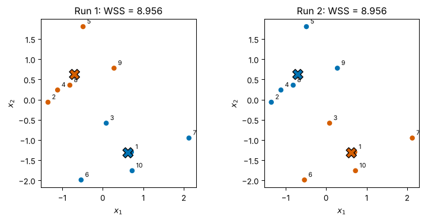

Final K-means fits from two different random starting assignments.

```
Same grouping (up to label names): True
WSS over 200 extra random starts (seed 4320):
 8.9557     192
17.3414      8
```

```python
runs = []
for r in (1, 2):
    init = random_assignment(10, 2, rng)
    out = my_kmeans(X, 2, init)
    runs.append(out)
    print(f"run {r}: start {init} -> final {out['labels']}, "
          f"iterations {out['iterations']}, WSS {out['wss']:.4f}")
    print(pd.DataFrame(out["means"].round(3), columns=["x1", "x2"]).to_string())
fig, axes = plt.subplots(1, 2, figsize=(8, 4))
for ax, out, r in zip(axes, runs, (1, 2)):
    plot_clusters(ax, X, out["labels"], out["means"], f"Run {r}: WSS = {out['wss']:.3f}")
plt.tight_layout(); plt.show()

same = (np.array_equal(runs[0]["labels"], runs[1]["labels"]) or
        np.array_equal(runs[0]["labels"], 1 - runs[1]["labels"]))
print("Same grouping (up to label names):", same)

# How often do random starts reach a different local optimum?
check_rng = np.random.default_rng(4320)
wss_many = pd.Series([round(my_kmeans(X, 2, random_assignment(10, 2, check_rng))["wss"], 4)
                      for _ in range(200)])
print("WSS over 200 extra random starts (seed 4320):\n", wss_many.value_counts().to_string())
```

**Yes, the two runs give the same grouping and the same objective, WSS = 8.956.** The cluster with points 2, 4, 5, 8, and 9 has mean $(-0.697,\,0.623)$, and the other five points have mean $(0.622,\,-1.316)$. Only the label names differ: run 1 calls the upper-left group cluster 1 and run 2 calls it cluster 0. That is expected, because K-means labels are arbitrary. Both runs converge within 2 iterations.

This doesn’t mean K-means always finds the best split. Each step can only lower the WSS, so the algorithm stops at a local minimum, and which one it reaches depends on the start. In 200 extra random starts, 192 reach WSS 8.956, but 8 stop at a worse fixed point with WSS 17.341. That’s why K-means is usually run from several starts, keeping the fit with the smallest WSS.

## Question 2: Image color compression

Pick your favorite color image and use your K-means function from Question 1 to cluster its pixels. For computational efficiency, resize the image to no more than $200\times200$ pixels and use its three RGB color channels.

1. Plot the original image and report its dimensions. Transform it into a data matrix with one observation per pixel and three variables: red, green, and blue. Report the dimensions of this matrix.
2. For $K=2,3,5,10$, apply your function to the pixel data. Report the cluster means and within-cluster sum of squares for each $K$. Reconstruct and plot each compressed image by replacing every pixel with its assigned cluster mean. Use the same RGB scale for all fits.
3. Which value of $K$ would you choose for this image? Briefly justify your choice using the reconstructed images and the within-cluster sums of squares.

**Answer 2.** I used the color photo `coffee` that ships with scikit-image, a cup of coffee on a saucer. To use your own image instead, replace the `img = ...` line with `img = plt.imread("your-photo.jpg")`.

**a.**

**Show the workflow**

```
original image: (400, 600, 3)  resized: (133, 200, 3)
pixel data matrix: (26600, 3)  (columns: red, green, blue)
```

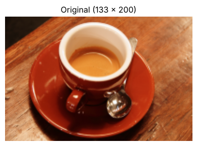

The original image, resized to 133 × 200 pixels.

```python
from skimage import data
from skimage.transform import resize

img = data.coffee()                                    # 400 x 600 x 3, values 0-255
small = resize(img, (133, 200), anti_aliasing=True)    # keep aspect ratio, values in [0, 1]
pixels = small.reshape(-1, 3)
print("original image:", img.shape, " resized:", small.shape)
print("pixel data matrix:", pixels.shape, " (columns: red, green, blue)")
fig, ax = plt.subplots(figsize=(5, 3.6))
ax.imshow(small); ax.set_title("Original (133 × 200)"); ax.axis("off")
plt.show()
```

The original image is $400\times600$ pixels with 3 channels. Resized to $133\times200$, keeping the aspect ratio, the pixel data matrix is $26{,}600\times3$, with one row per pixel and red, green, and blue values on a 0 to 1 scale.

**b.**

**Show the workflow**

```
K = 2: WSS = 1793.7, iterations = 21, cluster sizes = [13647, 12953]
  means (R, G, B on 0-255): [[116, 39, 17], [203, 136, 88]]
K = 3: WSS = 858.1, iterations = 20, cluster sizes = [14542, 6082, 5976]
  means (R, G, B on 0-255): [[174, 80, 39], [220, 169, 125], [58, 14, 7]]
K = 5: WSS = 375.5, iterations = 34, cluster sizes = [7846, 8771, 4570, 2463, 2950]
  means (R, G, B on 0-255): [[201, 128, 75], [171, 71, 32], [42, 11, 5], [234, 204, 176], [126, 33, 13]]
K = 10: WSS = 135.6, iterations = 92, cluster sizes = [3693, 1626, 1709, 1034, 2720, 3734, 3439, 1850, 3627, 3168]
  means (R, G, B on 0-255): [[194, 116, 64], [82, 18, 8], [132, 32, 12], [245, 232, 217], [152, 73, 36], [180, 93, 44], [175, 48, 17], [223, 180, 140], [35, 10, 5], [210, 143, 86]]
```

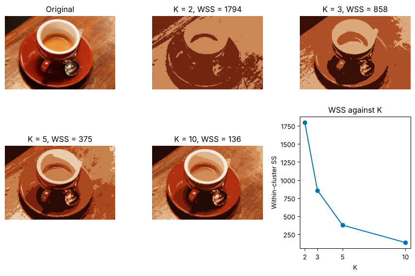

Images reconstructed by replacing each pixel with its cluster’s mean color. All panels use the same 0–1 RGB scale.

```python
img_rng = np.random.default_rng(432)
fits = {}
for K in (2, 3, 5, 10):
    fits[K] = my_kmeans(pixels, K, random_assignment(len(pixels), K, img_rng), max_iter=300)
    f = fits[K]
    print(f"K = {K}: WSS = {f['wss']:.1f}, iterations = {f['iterations']}, "
          f"cluster sizes = {np.bincount(f['labels'], minlength=K).tolist()}")
    print("  means (R, G, B on 0-255):", (f["means"] * 255).round().astype(int).tolist())

fig, axes = plt.subplots(2, 3, figsize=(9, 6.4))
axes = axes.ravel()
axes[0].imshow(small); axes[0].set_title("Original")
for ax, K in zip(axes[1:5], (2, 3, 5, 10)):
    f = fits[K]
    ax.imshow(np.clip(f["means"][f["labels"]].reshape(small.shape), 0, 1), vmin=0, vmax=1)
    ax.set_title(f"K = {K}, WSS = {f['wss']:.0f}")
Ks = [2, 3, 5, 10]
axes[5].plot(Ks, [fits[K]["wss"] for K in Ks], "o-", color="#0072B2")
axes[5].set(xlabel="K", ylabel="Within-cluster SS", title="WSS against K", xticks=Ks)
for ax in axes[:5]:
    ax.axis("off")
plt.tight_layout(); plt.show()
```

| $K$ | WSS | Cluster means (R, G, B on a 0–255 scale) |
| --- | --- | --- |
| 2 | 1,793.7 | (116, 39, 17), (203, 136, 88) |
| 3 | 858.1 | (174, 80, 39), (220, 169, 125), (58, 14, 7) |
| 5 | 375.5 | (201, 128, 75), (171, 71, 32), (42, 11, 5), (234, 204, 176), (126, 33, 13) |
| 10 | 135.6 | (194, 116, 64), (82, 18, 8), (132, 32, 12), (245, 232, 217), (152, 73, 36), (180, 93, 44), (175, 48, 17), (223, 180, 140), (35, 10, 5), (210, 143, 86) |

The fitting uses the 0 to 1 scale. Means are shown multiplied by 255 for readability.

**c.** **I would choose $K=10$.** The WSS keeps falling substantially at every step: 1,794 to 858 (down 52%) for $K=2$ to 3, 858 to 376 (down 56%) for 3 to 5, and 376 to 136 (down 64%) for 5 to 10. There is no point where adding colors stops paying off.

The reconstructions show the same thing. With $K=2$, the image is only light and dark: the cup is a light outline, and the coffee, saucer, and shadows merge into one dark brown. $K=3$ adds a middle brown, but the white rim, the crema, and the bright parts of the table share one tan color. $K=5$ separates the white rim from the table, and the cup is clearly recognizable, but the saucer is still the same orange-brown as the wood. Only at $K=10$ do the red saucer, the orange crema, and the highlights on the spoon come back, and the result looks close to the original.

Ten colors is still a large compression: each pixel needs one of 10 labels instead of three 0 to 255 values. If the goal were the smallest palette that keeps the objects recognizable, $K=5$ would be the minimal choice, but for a faithful-looking image I would use 10.

## Question 3: Hierarchical clustering of cars

The file `data/mtcars.csv` contains 11 numerical variables for 32 cars, including fuel economy, horsepower, and weight. The `car` column gives the model names; use it to label observations, not as a clustering variable. You may use existing hierarchical clustering functions for this question.

1. Standardize each numerical variable to have mean 0 and standard deviation 1. Using Euclidean distance, perform hierarchical clustering with single, complete, and average linkage. Plot the three dendrograms with the car names and compare the results.
2. Choose one linkage method and a number of clusters that you consider reasonable. Report the cluster memberships and a table of cluster means on the original variable scales. Describe the main characteristics of the groups and explain your choice using the dendrogram and table. Briefly explain why standardizing the variables matters for this analysis.

**Answer 3.**

**a.**

**Show the workflow**

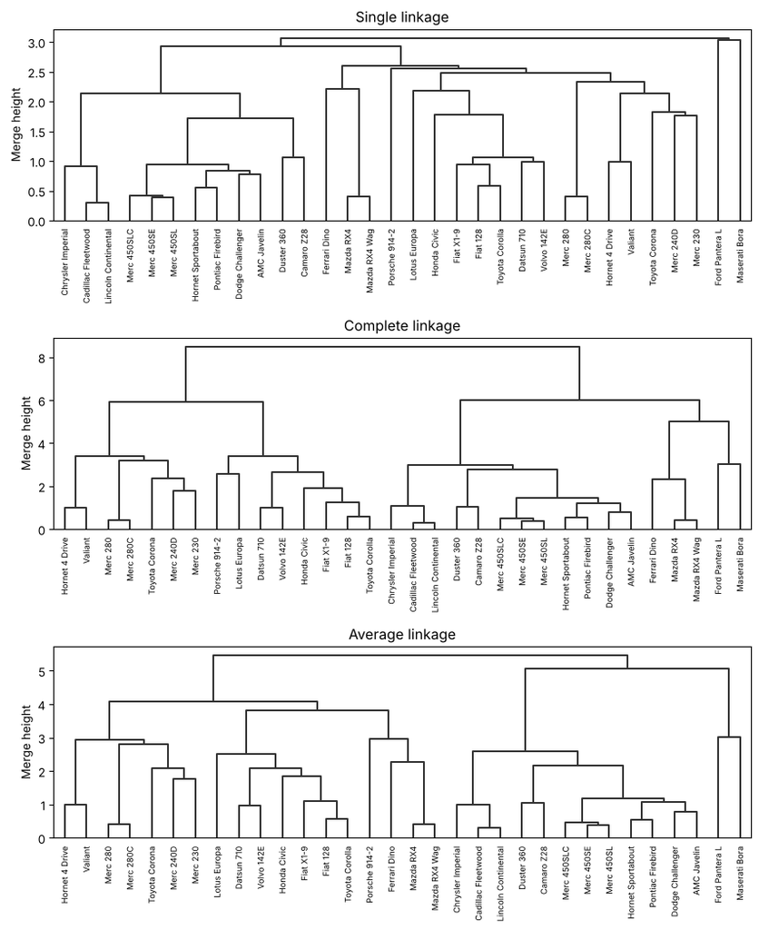

Dendrograms of the 32 cars from standardized variables with Euclidean distance.

```
  single: cluster sizes for k = 2, 3, 4 -> {2: [30, 2], 3: [30, 1, 1], 4: [12, 18, 1, 1]}
complete: cluster sizes for k = 2, 3, 4 -> {2: [15, 17], 3: [15, 12, 5], 4: [7, 8, 12, 5]}
 average: cluster sizes for k = 2, 3, 4 -> {2: [18, 14], 3: [18, 12, 2], 4: [7, 11, 12, 2]}
```

```python
from scipy.cluster.hierarchy import linkage, dendrogram, fcluster

cars = pd.read_csv("data/mtcars.csv")
vars_ = cars.drop(columns="car").columns
Zs = (cars[vars_] - cars[vars_].mean()) / cars[vars_].std(ddof=1)   # mean 0, SD 1
links = {m: linkage(Zs.to_numpy(), method=m, metric="euclidean")
         for m in ("single", "complete", "average")}

fig, axes = plt.subplots(3, 1, figsize=(9, 11))
for ax, (m, L) in zip(axes, links.items()):
    dendrogram(L, labels=cars["car"].tolist(), ax=ax, leaf_rotation=90, leaf_font_size=7,
               color_threshold=0, above_threshold_color="#333333")
    ax.set(title=f"{m.capitalize()} linkage", ylabel="Merge height")
plt.tight_layout(); plt.show()

for m, L in links.items():
    sizes = {k: np.bincount(fcluster(L, k, "maxclust"))[1:].tolist() for k in (2, 3, 4)}
    print(f"{m:>8}: cluster sizes for k = 2, 3, 4 -> {sizes}")
```

- **Single linkage** chains: cars are added to one growing group one at a time, the merge heights stay low and similar, and cutting into 2 or 3 clusters leaves one large cluster with only 1 or 2 cars split off (sizes 30 and 2, or 30, 1, and 1). The 2-cluster cut only isolates the Ford Pantera L and Maserati Bora. That flags unusual cars but doesn’t find groups.
- **Complete linkage** produces compact groups with clear gaps in the merge heights, splitting the cars into 15 and 17, then 15, 12, and 5.
- **Average linkage** falls in between. Its two main branches are almost the same as complete linkage’s, but at 3 clusters it splits off only the Ford Pantera L and Maserati Bora (sizes 18, 12, and 2).

**b.**

**Show the workflow**

```python
cars["cluster"] = fcluster(links["complete"], 3, criterion="maxclust")
for k, g in cars.groupby("cluster"):
    print(f"Cluster {k} ({len(g)} cars): " + ", ".join(g["car"]))
print(cars.groupby("cluster")[list(vars_)].mean().round(2).to_string())
```

```
Cluster 1 (15 cars): Datsun 710, Hornet 4 Drive, Valiant, Merc 240D, Merc 230, Merc 280, Merc 280C, Fiat 128, Honda Civic, Toyota Corolla, Toyota Corona, Fiat X1-9, Porsche 914-2, Lotus Europa, Volvo 142E
Cluster 2 (12 cars): Hornet Sportabout, Duster 360, Merc 450SE, Merc 450SL, Merc 450SLC, Cadillac Fleetwood, Lincoln Continental, Chrysler Imperial, Dodge Challenger, AMC Javelin, Camaro Z28, Pontiac Firebird
Cluster 3 (5 cars): Mazda RX4, Mazda RX4 Wag, Ford Pantera L, Ferrari Dino, Maserati Bora
           mpg   cyl    disp      hp  drat    wt   qsec    vs    am  gear  carb
cluster
1        24.65  4.53  131.65   91.33  3.90  2.58  19.16  0.93  0.53  3.93  1.80
2        15.05  8.00  357.62  194.17  3.12  4.10  17.14  0.00  0.00  3.00  3.08
3        18.50  6.80  223.40  198.80  3.84  3.00  15.62  0.00  1.00  4.60  5.20
```

I chose **complete linkage with 3 clusters**. The largest gap in the complete-linkage dendrogram is between the last two merges (about 6.0 and 8.5), which on height alone favors 2 clusters (15 and 17 cars). The 3-cluster cut sits in a narrower band (about 5.9 to 6.0). I still prefer 3, because it splits the 17-car branch into two groups that differ sharply in the table below, while every group stays large enough to describe. Going to 4 clusters only splits the economy cars into 7 heavier automatic sedans and 8 light manual cars, a smaller distinction.

| Cluster | n | mpg | cyl | disp | hp | drat | wt | qsec | vs | am | gear | carb |
| --- | --- | --- | --- | --- | --- | --- | --- | --- | --- | --- | --- | --- |
| 1 | 15 | 24.65 | 4.53 | 131.7 | 91.3 | 3.90 | 2.58 | 19.16 | 0.93 | 0.53 | 3.93 | 1.80 |
| 2 | 12 | 15.05 | 8.00 | 357.6 | 194.2 | 3.12 | 4.10 | 17.14 | 0.00 | 0.00 | 3.00 | 3.08 |
| 3 | 5 | 18.50 | 6.80 | 223.4 | 198.8 | 3.84 | 3.00 | 15.62 | 0.00 | 1.00 | 4.60 | 5.20 |

- **Cluster 1, economy cars (15):** Datsun 710, Fiat 128, Honda Civic, Toyota Corolla, the Mercedes 2xx sedans, Volvo 142E, and others. They are light (2.6 thousand lb), mostly 4-cylinder, low horsepower (91), and have the best fuel economy (24.7 mpg). Nearly all have straight engines (`vs` = 0.93).
- **Cluster 2, large American V8s (12):** Cadillac Fleetwood, Lincoln Continental, Camaro Z28, Merc 450 series, and others. They are heavy (4.1 thousand lb), all 8-cylinder, all automatic with 3 gears, have the largest displacement (358 cubic inches), and the worst fuel economy (15.1 mpg).
- **Cluster 3, high-performance manual cars (5):** Ferrari Dino, Maserati Bora, Ford Pantera L, and the two Mazda RX4s. They have high horsepower (199) but moderate weight (3.0 thousand lb), are all manual (`am` = 1) with 4 to 5 gears and many carburetors (5.2), and have the quickest quarter-mile times (15.6 s).

Clusters 2 and 3 have similar horsepower but differ sharply in transmission, gears, carburetors, and weight, which is why complete linkage keeps them apart.

**Why standardize.** Euclidean distance adds squared differences across variables, so variables measured in large units would dominate. On the raw scale, displacement (SD about 124 cubic inches) and horsepower (SD about 69) would decide almost every distance, while weight (SD about 1), `am`, and `vs` (0 to 1) would barely count. Standardizing gives each variable SD 1, so every variable contributes on an equal footing and the clusters reflect the overall design of the cars, not just engine size.